# Task 7 - 3

3. For the data set bricksq: ####(a) Split the data into two parts

```r
bricks1 <- window(bricksq, end=1987.99)
bricks2 <- window(bricksq, start=1988)
```

#### (b) Check that your data have been split appropriately by producing the following plot.

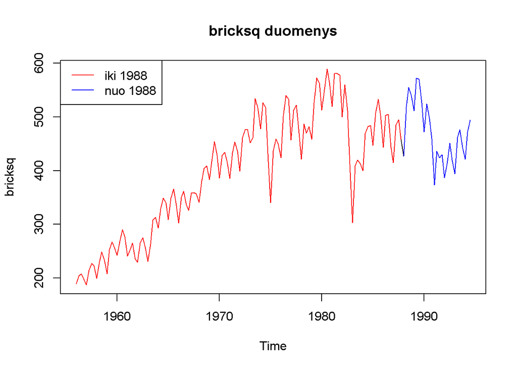

```r
plot(bricksq,main="bricksq duomenys")
lines(bricks1,col="red")
lines(bricks2,col="blue")
legend("topleft",legend= c("iki 1988", "nuo 1988"),col = c("RED","BLUE"),lty=1)
```

#### (c) Calculate forecasts using each of the four benchmark methods applied to bricks1.

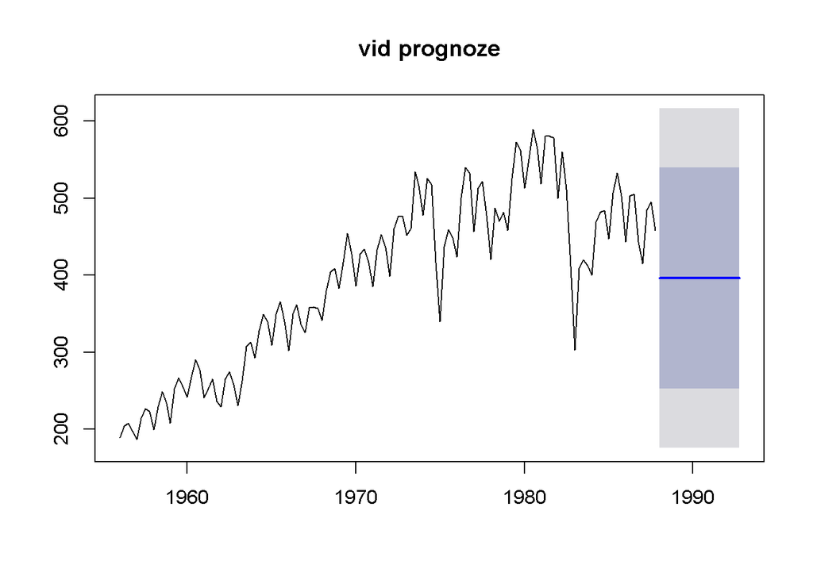

```r
vid <- meanf(bricks1, h=20)               # prognozė, lygi duomenų vidurkiui
plot(vid, main="vid prognozė")
```

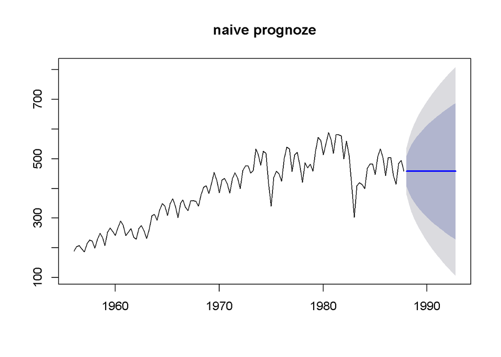

```r
naive <- naive(bricks1, h=20)             # prognozė, kuri atsižvelgia tik į paskutinę duomenų reikšmę
plot(naive, main="naive prognozė")
```

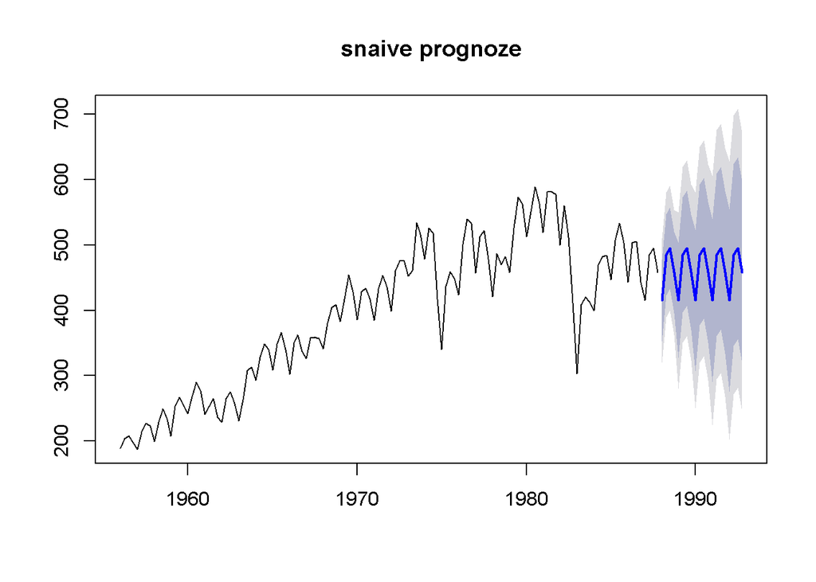

```r
snaive <- snaive(bricks1, h=20)           # preitas užfiksuotas sezonas yra naudojamas prognozuoti ateitį
plot(snaive, main="snaive prognozė")
```

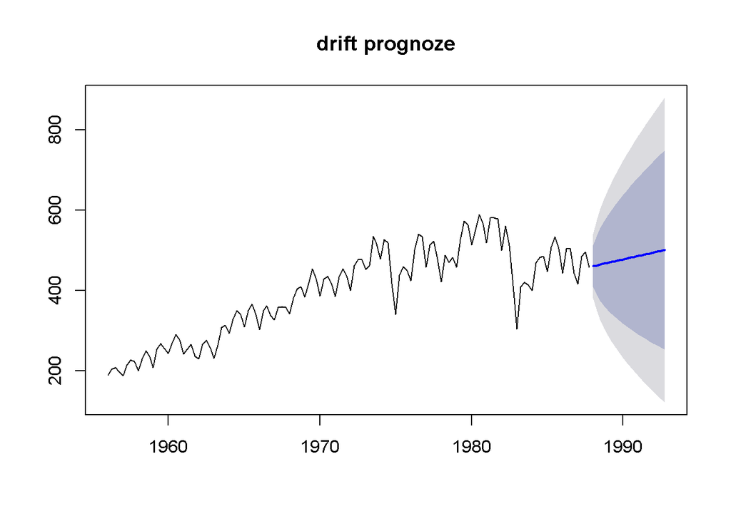

```r
drift <- rwf(bricks1, drift=TRUE, h=20)   # atsižvelgia į paskutinę duomenų reikšmę ir prideda vidutinį svyravimą
plot(drift, main="drift prognozė")
```

#### ((d) Compare the accuracy of your forecasts against the actual values stored in bricks2.

Štai prognozių tikslumas bricks2 duomenų atžvilgiu:

```r
kable(accuracy(vid,bricks2))
```

|  | ME | RMSE | MAE | MPE | MAPE | MASE | ACF1 | Theil’s U |
| --- | --- | --- | --- | --- | --- | --- | --- | --- |
| Training set | 0.00000 | 110.49649 | 95.04700 | -9.952875 | 28.71184 | 2.756919 | 0.9195361 | NA |
| Test set | 79.24531 | 99.37821 | 82.45625 | 15.320155 | 16.17221 | 2.391713 | 0.6787036 | 1.938198 |

```r
kable(accuracy(naive,bricks2))
```

|  | ME | RMSE | MAE | MPE | MAPE | MASE | ACF1 | Theil’s U |
| --- | --- | --- | --- | --- | --- | --- | --- | --- |
| Training set | 2.11811 | 40.15629 | 31.85039 | 0.1878701 | 8.173353 | 0.9238477 | -0.0720584 | NA |
| Test set | 17.30000 | 62.41394 | 53.40000 | 2.0757224 | 11.022361 | 1.5489123 | 0.6787036 | 1.250101 |

```r
kable(accuracy(snaive,bricks2))
```

|  | ME | RMSE | MAE | MPE | MAPE | MASE | ACF1 | Theil’s U |
| --- | --- | --- | --- | --- | --- | --- | --- | --- |
| Training set | 8.508064 | 48.60531 | 34.47581 | 2.001127 | 8.666006 | 1.000000 | 0.7955186 | NA |
| Test set | 12.050000 | 55.95132 | 49.25000 | 1.320529 | 10.243306 | 1.428538 | 0.8870064 | 1.155627 |

```r
kable(accuracy(drift,bricks2))
```

|  | ME | RMSE | MAE | MPE | MAPE | MASE | ACF1 | Theil’s U |
| --- | --- | --- | --- | --- | --- | --- | --- | --- |
| Training set | 0.000000 | 40.10039 | 31.83930 | -0.3959664 | 8.187045 | 0.9235258 | -0.0720584 | NA |
| Test set | -4.940157 | 69.01887 | 62.17874 | -2.9014741 | 13.421454 | 1.8035471 | 0.7498292 | 1.480593 |

Manau pagal MPE ir ME nereikėtų rinktis modelio, nes ne absoliučios reikšmės skaičiuojamos. Geriau naudoti RMSE rodiklį, nes ima absoliučius dydžius ir padidina mažina išskirčių turinčias prognozės patrauklumą, nes paklaidos pakeliamos kvadratu. Taip pat labai patogus MAE rodiklis, nes imamos absoliučių paklaidų vidurkis. Taigi naudingi rodikliai RMSE: Root Mean Squared Error, MAE: Mean Absolute Error, šiuo atveju mažai kreipsiu dėmesį į MAPE: Mean Absolute Percentage Error, MASE: Mean Absolute Scaled Error, ACF1: Autocorrelation of errors at lag 1.

Taigi žiūrėsime į naudingiausius rodiklius. vid prognozės rodikliai:

```r
kable(accuracy(vid,bricks2)[,c(2,3)])
```

|  | RMSE | MAE |
| --- | --- | --- |
| Training set | 110.49649 | 95.04700 |
| Test set | 99.37821 | 82.45625 |

naive prognozės rodikliai:

```r
kable(accuracy(naive,bricks2)[,c(2,3)])
```

|  | RMSE | MAE |
| --- | --- | --- |
| Training set | 40.15629 | 31.85039 |
| Test set | 62.41394 | 53.40000 |

snaive prognozės rodikliai:

```r
kable(accuracy(snaive,bricks2)[,c(2,3)])
```

|  | RMSE | MAE |
| --- | --- | --- |
| Training set | 48.60531 | 34.47581 |
| Test set | 55.95132 | 49.25000 |

drift prognozės rodikliai:

```r
kable(accuracy(drift,bricks2)[,c(2,3)])
```

|  | RMSE | MAE |
| --- | --- | --- |
| Training set | 40.10039 | 31.83930 |
| Test set | 69.01887 | 62.17874 |

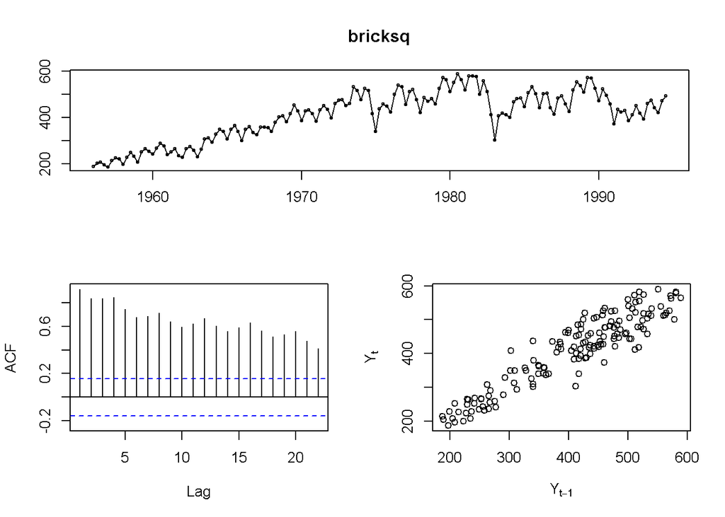

```r
tsdisplay(bricksq, plot.type="scatter")      #kas keturis pikas, nurodantis metinį ketverčio sezoniškumą, matomi ciklai
```

Metodų ir duomenų grafikas:

(idėja gauta https://www.otexts.org/fpp/2/5)

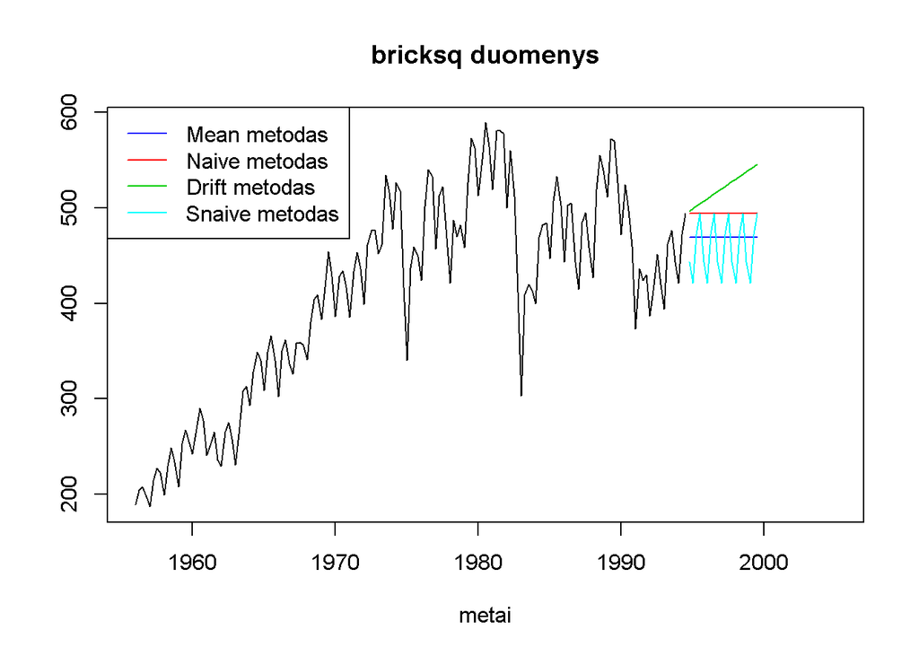

```r
plot(bricksq, main="bricksq duomenys",
  ylab="", xlab="metai", xlim=c(1956,2005))
lines(meanf(bricks2,h=20)$mean, col=4)
lines(rwf(bricks2,h=20)$mean, col=2)
lines(rwf(bricks2,drift=TRUE,h=20)$mean, col=3)
lines(snaive(bricks2,h=20)$mean, col=5)
legend("topleft", lty=1, col=c(4,2,3,5),
  legend=c("Mean metodas","Naive metodas","Drift metodas","Snaive metodas"))
lines(bricks2)
```

#### ((f) For the best method, compute the residuals and plot them.

Kaip matome yra dėsningumas tarp paklaidų:

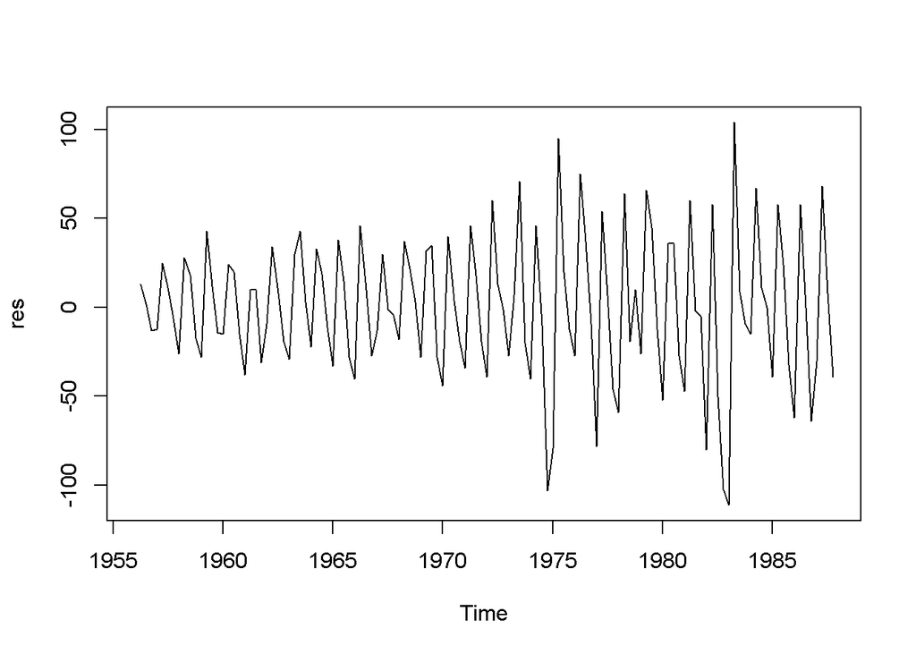

```r
naive=naive(bricks2,h=20)
res <- residuals(drift)
plot(res)
```

Do the residuals appear to be uncorrelated and normally dis- tributed?

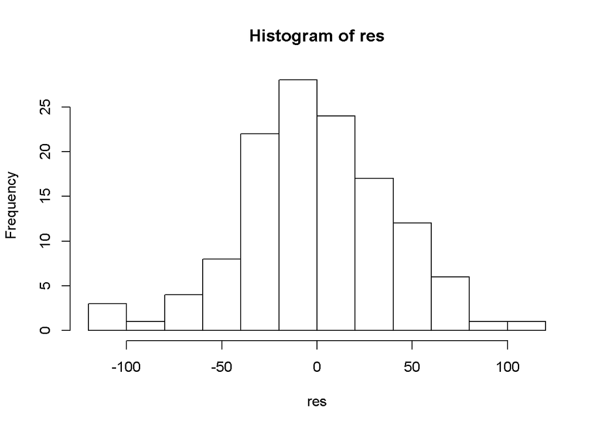

```r
hist(res, breaks="FD")
```

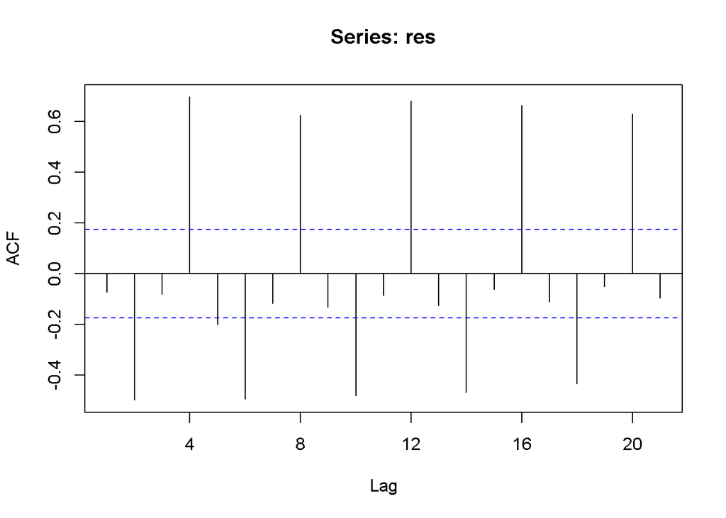

```r
Acf(res)
```